# Notes 2 - Biostatistics Boot Camp 2

Linda Kukolich

February 2, 2015

# Two sample Binomial Tests

- Consider a rondomized trial where 40 subjects were randomized (20 each) to two drugs with the same active ingredient but different expedients
- Consider counting the number of subjects with side effects for each drug

|  | Side |  |  |
| --- | --- | --- | --- |
|  | Effects | None | total |
| Drug A | 11 | 9 | 20 |
| Drug B | 5 | 15 | 20 |
| Total | 16 | 14 | 40 |

```r
df <- data.frame(SideEffects=c(11,5, 16), NoSideEffect=c(9,15, 14), total=c(20, 20, 40), row.names=c("A", "B", "Total"))
df
```

```
##       SideEffects NoSideEffect total
## A              11            9    20
## B               5           15    20
## Total          16           14    40
```

## The score statistic

### Hypothesis tests for binomial proportions

Start by only considering Drug A

- Consider testing $H_0 : p = p0$ for a binomial proportion
- The **score** test statistic $\frac{\hat{p} - p_0}{\sqrt{p_0(1-p_0)/n}}$

follows a Z distribution for large n

- This test performs better than the Wald test $\frac{\hat{p} - p_0}{\sqrt{\hat{p}(1-\hat{p})/n}}$

### Inverting the two intervals

- Inverting the Wald test yields the Wald interval $\hat{p} \pm Z_{1-\alpha/2}\sqrt{\hat{p}(1-\hat{p})/n}$
- Inverting the Score test yields the Score interval $\hat{p} \big(\frac{n}{n+Z^2_{1-\alpha/2}} \big) + \frac{1}{2} \big(\frac{Z^2_{1-\alpha/2}}{n+Z^2_{1-\alpha/2}} \big) \\ \pm Z_{1-\alpha/2}\sqrt{\frac{1}{n+Z^2_{1-\alpha/2}}\big[\hat{p}(1-\hat{p})\big(\frac{n}{n+Z^2_{1-\alpha/2}} \big) + \frac{1}{4}\big(\frac{Z^2_{1-\alpha/2}}{n + Z^2_{1-\alpha/2}} \big) \big]}$

To make this look nicer, Let $q = \frac{n}{n+Z^2_{1-\alpha/2}}$

$\hat{p}q + \frac{1-q}{2} \pm Z_{1-\alpha/2}\sqrt{q/n[\hat{1}(1-\hat{p})q + \frac{1-q}{4}]}$

- Plugging in $Z_{1-\alpha/2} = 2$ yields the Agresti/Coull interval (about 2, so $\alpha \approx 0.5$)

### Example

```r
na <- df["A", "total"]
phat <- df["A", "SideEffects"] / na
p0 = 0.1
ts <- (phat - p0)/sqrt(p0*(1-p0)/na)
ts
```

```
## [1] 6.708204
```

```r
power <- pnorm(ts, lower.tail=FALSE)
power
```

```
## [1] 9.851722e-12
```

```r
if (power > .95) {
    print(paste("Reject the null hypothesis (accept that ", phat, ">", p0, ")"))
} else {
    print(paste("Fail to reject the null hypotheis (accept that ", phat, "<=", p0, ")"))
}
```

```
## [1] "Fail to reject the null hypotheis (accept that  0.55 <= 0.1 )"
```

We have assumed that the population is independent, which is not necessarily a good assumption. (IID model)

## Exact tests

- consider calculating an exact P-value
- What’s the probability, under the null hypothesis, of getting evidence as extreme or more extreme than we obtained?

$P(X_A \ge 11) = \sum_{x=11}^{20} {20 \choose x} 0.1^x \times (1-0.1)^{20-x} \approx 0$

```r
pbinom(10, 20, .1, lower.tail = FALSE)
```

```
## [1] 7.088606e-07
```

```r
binom.test(11, 20, .1, alternative = "greater")
```

```
##
##  Exact binomial test
##
## data:  11 and 20
## number of successes = 11, number of trials = 20, p-value =
## 7.089e-07
## alternative hypothesis: true probability of success is greater than 0.1
## 95 percent confidence interval:
##  0.3469314 1.0000000
## sample estimates:
## probability of success
##                   0.55
```

- This test, unlike the asymptotic ones, guarantees the Type I error rate is less than desired level; sometimes it is much less
- Inverting the exact binomial test yields an exact binomial interval for the true proportion
- This interval (the Clopper/Pearson interval) has coverage greater than 95%, though can be very conservative
- For two sided tests, calculate the two one sided P-values and double the smaller

## Comparing two binomial proportions

- Consider now testing whether the proportion of side effects is the same in the two groups
- Let $X \sim \mathrm{Binomial}(n_1, p_1)$ and $\hat{p}_2 = X/n_1$
- Let $Y \sim \mathrm{Binomial}(n_2, p_2)$ and $\hat{p}_2 = Y/n_2$
- We also use the following notation:

| $n_{11} = X$ | $n_{12} = n_1 - X$ | $n_1 = n_{1+}$ |
| --- | --- | --- |
| $n_{21} = Y$ | $n_{22} = n_2 - X$ | $n_2 = n_{2+}$ |
| $n_{+1}$ | $n_{+2}$ |  |

- Consider testing $H_0 : p_1 = p_2$
- Versus $H_1 : p_1 \ne p_2$, $H_2 : p_1 \gt p_2$, $H_3 : p_1 \lt p_2$
- The score test statistic for this null hypothesis is

$TS = \frac{\hat{p}_1 - \hat{p}_2}{\sqrt{\hat{p}(1-\hat{p})(\frac{1}{n_1} + \frac{1}{n_2})}}$

where $\hat{p} = \frac{X + Y}{n_1 + n_2}$ is the estimate of the common proportion under the null hypothesis

- This statistic is normally distributed for large $n_1$ and $n_2$.
- This interval does not have a closed form inverse for creating a confidence interval (though the numerical interval obtained performs well)
- An alternate interval inverts the Wald test

$TS = \frac{\hat{p}_1 - \hat{p}_2}{\sqrt{\frac{\hat{p}_1(1 - \hat{p}_1)}{n_1} + \frac{\hat{p}_2(1-\hat{p}_2)}{n_2}}}$

- The resulting confidence interval is $\hat{p}_1 - \hat{p}_2 \pm Z_{1 - \alpha/2} \sqrt{\frac{\hat{p}_1(1-\hat{p}_1)}{n_1} + \frac{\hat{p}_2(1 - \hat{p}_2)}{n_2}}$
- As in the one sample case, the Wald interval and test performs poorly relative to the score interval and test
- For testing, always use the score test
- For intervals, inverting the score test is hard and not offered in standard software
- A simple fix is the Agresti/Caffo interval which is obtained by calculating $\tilde{p}_1 = \frac{x+1}{n_1 + 2}$, $\tilde{n}_1 = n_1 + 2$, $\tilde{p}_2 = \frac{y + 1}{n_2 + 2}$ and $\tilde{n}_2 = (n_2 + 2)$
- Using these, simply construct the Wald interval

```r
n11 <- df["A", "SideEffects"]
n1 <- df["A", "total"]
n21 <- df["B", "SideEffects"]
n2 <- df["B", "total"]
n1_tilde <- n1 + 2
p1_tilde <- (n11+1)/n1_tilde
n2_tilde <- n2 + 2
p2_tilde <- (n21+1)/n2_tilde
z975 <- qnorm(1-0.025)
# Agresti/Caffo interval
ac_int <- p1_tilde - p2_tilde + c(-1, 1) *z975 * sqrt(p1_tilde * (1-p1_tilde)/n1_tilde + p2_tilde * (1-p2_tilde) / n2_tilde)
ac_int
```

```
## [1] -0.006424857  0.551879402
```

### Example

- Test whether or not the proportion of side effects is the same for the two drugs
- $\hat{p}_A = .55, \hat{p}_B = 5/20 = .25, \hat{p} = 16/40 = .4$
- Test statistic

*My Numbers Do Not Match His* His can be approximated with .25/sqrt(.024). I think he left off a parenthesis in his R code.

```r
n_a <- df["A", "total"]
phata <- df["A", "SideEffects"] / n_a
n_b <- df["B", "total"]
phatb <- df["B", "SideEffects"] / n_b
n <- df["Total", "total"]
phat <- df["Total", "SideEffects"] / n
ts <- (phata - phatb)/sqrt(phat * (1-phat) * (1/n_a + 1/n_b))
z975 <- qnorm(.975)
if (abs(ts) >= z975) {
    print(paste(ts, ">=", z975, "Reject null hypothesis"))
} else {
    print(paste(ts, "<", z975, "Fail to reject null hypothesis"))
}
```

```
## [1] "1.93649167310371 < 1.95996398454005 Fail to reject null hypothesis"
```

```r
pvalue <- 2*pnorm(ts, lower.tail=FALSE)
pvalue
```

```
## [1] 0.05280751
```

## Bayesian and likelihood analysis for two binomial proportions

- Likelihood analysis requires the use of profile likelihoods, or some other technique and so we omit their discussion
- Consider putting independent $\mathrm{Beta}(\alpha_1, \beta_1)$ and $\mathrm{Beta}(\alpha_2, \beta_2)$ priors on $p_1$ and $p_2$ respectively
- Then the posterior is

$\pi(p_1, p_2) \propto p_1^{x + \alpha_1 - 1} (1-p_1)^{n_1 + \beta_1 - 1} \times p_2^{y+\alpha_2 - 1} (1-p_2)^{n_2 + \beta_2 - 1}$

- Hence under this (potentially naive) prior, the posterior for $p_1$ and $p_2$ are independent betas
- The easiest way to explore this posterior is via Monte Carlo simulation

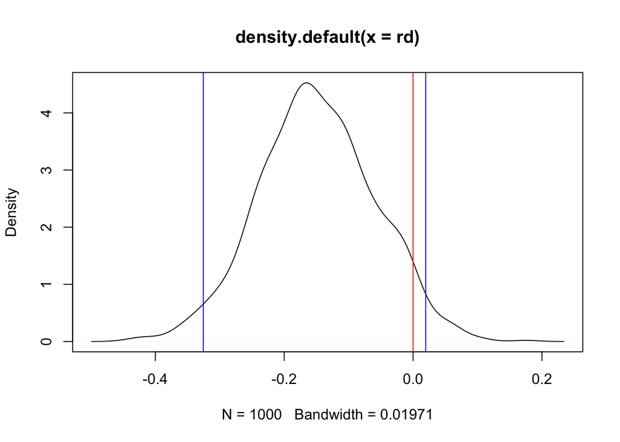

```r
x <- 11; n1 <- 20; alpha1 <- 1; beta1 <- 1
y <- 5; n2 <- 20; alpha2 <- 1; beta2 <- 1
p1 <- rbeta(1000, x + alpha1, n - x + beta1)
p2 <- rbeta(1000, y + alpha2, n-y+beta2)
rd <- p2 - p1
plot(density(rd))
abline(v=0, col="red")
abline(v=quantile(rd, .025), col="blue")
abline(v=quantile(rd, .975), col="blue")
```

```r
quantile(rd, c(.025, .975))
```

```
##        2.5%       97.5%
## -0.32553904  0.01968889
```

```r
mean(rd)
```

```
## [1] -0.1487081
```

```r
median(rd)
```

```
## [1] -0.1523862
```

- mn = mean
- med = median
- mod = mode
- rd = risk difference
- rr = risk ratio
- or = odds ratio

```r
source("twoBinomPost.R")
twoBinomPost(x, n1, y, n1)
```

```
## Post mn rd (mcse) = -0.275 (0.004)
## Post mn rr (mcse) = 0.518 (0.007)
## Post mn or (mcse) = 0.361 (0.008)
##
## Post med rd       =  -0.277
## Post med rr       =  0.494
## Post med or       =  0.292
##
## Post mod rd       =  -0.277
## Post mod rr       =  0.433
## Post mor or       =  0.198
##
## Equi-tail rd      =  -0.555 0.009
## Equi-tail rr      =  0.192 1.024
## Equi-tail or      =  0.073 1.038
```

He then shows a plot of Risk difference, without the code to generate it.

# Relative Risks and Odds Ratios

# Two sample binomials results

X is n1 samples from a binomial distribution with probability p1 $X \sim \mathrm{Bin}(n_1, p_1)$ and Y is n2 samples from a Bin(n2, p2) Which is often arranged in the following table:

| $n_{11} = x$ | $n_{12} = n_1 - x$ | $n_1$ |
| --- | --- | --- |
| $n_{21} = y$ | $n_{22} = n_2 - y$ | $n_2$ |

- Last time, we considered the absolute change in the proportions, what about relative changes?
- Relative changes are often of more interest than absolute, eg when both proportions are small
- The **relative risk** is defined as $p_1/p_2$
- The natural estimator for the relative risk is

$\hat{RR} = \frac{\hat{p}_1}{\hat{p}_2} = \frac{X/n_1}{Y/n_2}$

- The standard error for log $\hat{RR}$ is

$\hat{SE}_{log{\hat{RR}}} = \big(\frac{(1-p_1)}{p_1n_1} + \frac{1-p_2}{p_2n_2} \big)^{1/2}$

- Exponentiate the resulting interval to get an interval for the RR
- The **odds ratio** is defined as

$\frac{\mathrm{Odds\,of\,SE\,Drug\,A}}{\mathrm{Odds\,of\,SE\,Drug\,B}} = \frac{p_1/(1-p_1)}{p_2/(1-p_2)} = \frac{p_1(1-p_2)}{p_2(1-p_1)}$

- The sample odds ratio simply plus in the estimates for $p_1$ and $p_2$, this works out to have a convenient form

$\hat{OR} = \frac{\hat{p1}/(1-\hat{p1})}{\hat{p_2}/(1 - \hat{p}_2)} = \frac{n_{11}n_{22}}{n_{12}n_{21}}$

(cross product ratio)

- The standard error for log $\hat{OR}$ is

$\hat{SE}_{log\hat{OR}} = \sqrt{\frac{1}{n_{11}} + \frac{1}{n_{12}} + \frac{1}{n_{21}} + \frac{1}{n_{22}}}$

- Exponentiate the resulting interval to obtain an interval for the OR
- Notice that the sample and true odds ratios do not change if we transpose the rows and the columns
- For both the OR and RR, taking the logs helps with adherence to the error rate
- Of course the interval for the log RR or log OR is obtained by taking

$Estimate \pm Z_{1-\alpha/2}SE_{Estimate}$

- Exponentiating yeilds an interval for the OR or RR
- Though logging helps, these intervals still don’t perform altogether that well

### Example - RR

- For the relative risk, $\hat{p}_A = 11/20 = .55$, $\hat{p}_B = 5/20 = .25$
- $\hat{RR}_{A/B} = .55/.25 = 2.2$
- $\hat{SE}_{log\hat{RR}_{A/B}} = \sqrt{\frac{1-.55}{.55\times 20} + \frac{1-.25}{.25 \times 20}} = .44$
- Interval for the log RR: log(2.2) $\pm 1.95 \times .44 = [-.07, 1.65]$ (contains 0, not *significant*)
- Interval for the RR: [.93, 5.21] (contains 1, not *significant*)

```r
nse_a <- 11
n_a <- 20
nse_b <- 5
n_b <- 20
phat_a <- nse_a/n_a
phat_b <- nse_b/n_b
rr_ab <- phat_a/phat_b
print(paste("Risk Ratio A/B", rr_ab))
```

```
## [1] "Risk Ratio A/B 2.2"
```

```r
se_log_rr_ab <- sqrt((1-phat_a)/(phat_a*n_a) + (1-phat_b)/(phat_b*n_b))
print(paste("Squared Error of log RR A/B:", se_log_rr_ab))
```

```
## [1] "Squared Error of log RR A/B: 0.436931448752651"
```

```r
log_rr_int <- log(rr_ab) + c(-1, 1) * qnorm(.975) * se_log_rr_ab
print(paste("Interval for log RR", log_rr_int[1], log_rr_int[2]))
```

```
## [1] "Interval for log RR -0.0679125429038346 1.64482726363238"
```

```r
rr_int <- exp(log_rr_int)
print(paste("Interval for RR", rr_int[1], rr_int[2]))
```

```
## [1] "Interval for RR 0.934342184858358 5.18011503540721"
```

### Example - OR

- $\hat{OR}_{A/B} = \frac{11\times 15}{9\times 5} = 3.67$
- $\hat{SE}_{log\hat{OR}_{A/B}} = \sqrt{\frac{1}{11} + \frac{1}{9} + \frac{1}{5} + \frac{1}{15}} = .68$
- Interval for log OR: log(3.67) ± 1.96 × .68 = [-.04, 2.64]
- Interval for the OR: [.96, 14.01]

```r
nnse_a <- n_a - nse_a
nnse_b <- n_b - nse_b
orhat_ab <- (nse_a * nnse_b)/(nnse_a * nse_b)
orhat_ab
```

```
## [1] 3.666667
```

```r
se_log_orhat_ab = sqrt(1/nse_a + 1/nnse_a + 1/nse_b + 1/nnse_b)
se_log_orhat_ab
```

```
## [1] 0.6846071
```

```r
log_or_int <- log(orhat_ab) + c(-1, 1) * z975 * se_log_orhat_ab
print(paste("Log Odds ratio interval:", log_or_int[1], log_or_int[2]))
```

```
## [1] "Log Odds ratio interval: -0.0425222572742734 2.6410882255348"
```

```r
or_int <- exp(log_or_int)
print(paste("Odds ratio interval:", or_int[1], or_int[2]))
```

```
## [1] "Odds ratio interval: 0.95836913459888 14.0284614341963"
```

### Risk Differece

```r
rd_ab <- phat_a - phat_b
print(paste("Risk Difference A-B", rd_ab))
```

```
## [1] "Risk Difference A-B 0.3"
```

```r
se_rd_ab <- sqrt(phat_a*(1-phat_a)/n_a + phat_b*(1-phat_b)/n_b)
print(paste("Square Error Risk Difference A-B", se_rd_ab))
```

```
## [1] "Square Error Risk Difference A-B 0.147478812037526"
```

```r
rd_int <- rd_ab + c(-1, 1) * z975 * se_rd_ab
print(paste("Risk Difference Interval:", rd_int[1], rd_int[2]))
```

```
## [1] "Risk Difference Interval: 0.0109468399236965 0.589053160076304"
```

*Shows a plot of the posterior, which lets us see that while our Risk Ratio/Odds Ratio is not significant, that it IS close. Which we do not get a sense of without seeing the posterior plot.*

### Summary

| $n_{11} = x$ | $n_{12} = n_1 - x$ | $n_1$ |
| --- | --- | --- |
| $n_{21} = y$ | $n_{22} = n_2 - y$ | $n_2$ |

- Risk Difference: $\hat{RD} = \hat{p}_1 - \hat{p}_2$
- Error in Risk Difference: $\hat{SE}_\hat{RD} = \sqrt{\frac{\hat{p}_1(1-\hat{p}_1)}{n_1} + \frac{\hat{p}_2(1-\hat{p}_2)}{n_2}}$
- Risk Ratio: $\hat{RR} = \frac{\hat{p}_1}{\hat{p}_2}$
- Error in Risk Ratio: $\hat{SE}_{log\hat{RR}} = \sqrt{\frac{(1-\hat{p}_1)}{\hat{p}_1 n_1} + \frac{(1-\hat{p}_2)}{\hat{p}_2 n_2}}$
- Odds Ratio: $\hat{OR} = \frac{\hat{p}_1/(1-\hat{p}_1)}{\hat{p}_2/(1-\hat{p}_2} = \frac{n_{11}n_{22}}{n_{12}n_{21}}$
- Error in Odds Ratio = $\hat{SE}_{log\hat{OR}} = \sqrt{ \frac{1}{n_{11}} + \frac{1}{n_{12}} + \frac{1}{n_{21}} \frac{1}{n_{22}}}$
- Confidence Interval = Estimate $\pm Z_{1-\alpha/2}\mathrm{SE_{Est}}$

# Delta Method and Standard Errors

- **delta method** can be used to obtain large sample standard errors
- Formally, the delta methods states that if $\frac{\hat\theta - \theta}{\hat{SE}_\hat{\theta}} \rightarrow \mathrm{N}(0,1)$

then

$\frac{f(\hat\theta) - f(\theta)}{f'(\hat\theta)\hat{SE}_\hat\theta} \rightarrow \mathrm{N}(0, 1)$

- Asymptotic mean of $f(\hat\theta)$ is $f(\theta)$
- Asymptotic standard error of $f(\hat\theta)$ can be estimated with $f'(\hat\theta)\hat{SE}_\hat\theta$

## Example

- $\theta = \hat{p}_1$
- $\hat\theta = \hat{p}_1$
- $\hat{SE}_\hat\theta = \sqrt{\frac{\hat{p}_1(1-\hat{p}_1)}{n_1}}$
- $f(x) = \mathrm{log}(x)$
- $f'(x) = 1/x$
- $\frac{\hat\theta - \theta}{\hat{SE}_\hat\theta} \rightarrow$ N(0, 1) by the CLT
- Then $\hat{SE}_{\mathrm{log}\hat{p}_1} = f'(\hat\theta)\hat{SE}_\hat\theta$ $= \frac{1}{\hat{p}_1}\sqrt{\frac{\hat{p}_1(1 - \hat{p}_1)}{n_1}} = \sqrt{\frac{(1 - \hat{p}_1)}{\hat{p}_1n_1}}$
- And $\frac{\mathrm{log}\hat{p}_1 - \mathrm{log}p_1}{\sqrt{\frac{(1-\hat{p}_1)}{\hat{p}_1n_1}}} \rightarrow \mathrm{N}(0, 1)$

## Putting it all together

- Asymptotic standard error (The plus there is correct, variance of RR is sum of the log variances, not the differences)

$\begin{align} \mathrm{Var}(\mathrm{log}\hat{RR}) & = \mathrm{Var}(\mathrm{log}(\hat{p}_1 / \hat{p}_2))\\ & = \mathrm{Var}(\mathrm{log}\hat{p}_1) + \mathrm{Var}(\mathrm{log}\hat{p}_2) \\ & \approx \frac{(1-\hat{p}_1)}{\hat{p}_1 n_1} + \frac{(1 - \hat{p}_2)}{\hat{p}_2 n_2} \end{align}$

- The last line following from the delta method
- The approximation requires large sample sizes
- The delta method can be used similarly for the log odds ratio

## Motivation for the delta method

- If $\hat\theta$ is close to $\theta$ then (which it is for a large enough n) $\frac{f(\hat\theta) - f(\theta)}{\hat\theta - \theta} \approx f'(\hat\theta)$
- So $\frac{f(\hat\theta) - f(\theta)}{ft(\hat\theta)} \approx \hat\theta - \theta$
- Therefore $\frac{f(\hat\theta) - f(\theta)}{f'(\hat\theta)} \approx \frac{\hat\theta}{\hat{SE}_\hat\theta}$